# 05a_SMART_Marginal_Fitting_Is_Employed

```python
%matplotlib inline
```

**Marginal Fitting: Is Employed**

- *is_employed* is fixed to match the proportions per age predicted by the BFS
- The choice of persons to fix is done with a probability model based on their *current_edu* and *current_job_rank*

```python
import logging
import os
import sys

from matplotlib import pyplot as plt
import pandas as pd
import numpy as np
```

```python
sys.path.append(r'\\Filer16L\P-V160L\SIMBA.A11244\90_Persoenlich\u229285\dev\SynPopToolbox')
```

```python
from synpop import marginal_fitting, utils
from synpop.synpop import Persons
from synpop.visualisations import save_figure, plot_binary_feature_per_age_with_marginals, plot_ct1, plot_ct2, plot_ct3
from synpop.visualisations import plot_multi_class_feature_per_age
from synpop.marginals import FSO_ActivePopPredictionsClient
```

```python
logger = logging.getLogger()
logger.setLevel(logging.DEBUG)  # Set logging level: WARNING, INFO, DEBUG
```

# Settings

```python
YEAR_IST = 2017
YEAR = 2040

DATA_DIR_IST = r'\\k13536\mobi\10_Daten\SynPop\2017\190813_CH_2017_BEST1\02_preprocessed'
SYNPOP_PERSONS_FILE_IST = os.path.join(DATA_DIR_IST, f'persons_{YEAR_IST}.pickle.gzip')

DATA_DIR = r'\\k13536\mobi\10_Daten\SynPop\2040\02_preprocessed'
SYNPOP_PERSONS_FILE = os.path.join(DATA_DIR, f'persons_{YEAR}.pickle.gzip')

FIXED_ATTRIBUTES_DIR = 'outputs'
```

**Export Settings**

```python
SAVE_OUTPUTS = True
OUTPUT_DIR = './outputs'
FIG_FORMAT = 'png'
FIG_DPI = 150
FIG_BBOX_INCHES = 'tight'
FIG_PAD_INCHES = 0.2
```

```python
utils.create_dir(OUTPUT_DIR)
```

```
2020-04-22 17:07:24,630 - INFO - synpop.utils: "./outputs" exists already
```

# Loading Data

## SynPop

```python
COLUMNS_OF_INTEREST = ['person_id', 'level_of_employment', 'position_in_bus', 'position_in_edu', 'age', 'location_id',
                       'is_employed', 'loe_group', 'current_edu', 'current_job_rank', 'is_apprentice',
                       'KT', 'N_KT', 'ID_Gem', 'N_Gem', 'KT_full' ]
```

**Scenario Year**

```python
SYNPOP_PERSONS_FILE
```

```
'\\\\k13536\\mobi\\10_Daten\\SynPop\\2040\\02_preprocessed\\persons_2040.pickle.gzip'
```

```python
%%time
synpop_persons = Persons(YEAR)
synpop_persons.load_pickle(SYNPOP_PERSONS_FILE)

fixed_edu = pd.read_pickle(os.path.join(FIXED_ATTRIBUTES_DIR, f'fixed_current_edu_SMART.pickle.gzip'), compression='gzip')
synpop_persons.overwrite_column('current_edu', fixed_edu)

fixed_job = pd.read_pickle(os.path.join(FIXED_ATTRIBUTES_DIR, f'fixed_current_job_rank_SMART.pickle.gzip'), compression='gzip')
synpop_persons.overwrite_column('current_job_rank', fixed_job)

persons = synpop_persons.data[COLUMNS_OF_INTEREST].copy(deep=True)

del synpop_persons
```

```
2020-04-22 17:07:24,688 - INFO - synpop.synpop: Loading \\k13536\mobi\10_Daten\SynPop\2040\02_preprocessed\persons_2040.pickle.gzip ...
2020-04-22 17:07:41,785 - INFO - synpop.synpop: Table persons loaded with 10037464 rows.
2020-04-22 17:07:42,792 - INFO - synpop.synpop: Overwriting "current_edu" with new values ...
2020-04-22 17:07:55,414 - DEBUG - synpop.synpop: Columns "current_edu" has been dropped.
2020-04-22 17:08:04,250 - INFO - synpop.synpop: "current_edu" has been overwritten.
2020-04-22 17:08:05,292 - INFO - synpop.synpop: Overwriting "current_job_rank" with new values ...
2020-04-22 17:08:18,207 - DEBUG - synpop.synpop: Columns "current_job_rank" has been dropped.
2020-04-22 17:08:27,205 - INFO - synpop.synpop: "current_job_rank" has been overwritten.
```

```
Wall time: 1min 8s
```

**Year IST**

```python
SYNPOP_PERSONS_FILE_IST
```

```
'\\\\k13536\\mobi\\10_Daten\\SynPop\\2017\\190813_CH_2017_BEST1\\02_preprocessed\\persons_2017.pickle.gzip'
```

```python
%%time
synpop_persons_ist = Persons(YEAR_IST)
synpop_persons_ist.load_pickle(SYNPOP_PERSONS_FILE_IST)

persons_ist = synpop_persons_ist.data[COLUMNS_OF_INTEREST].copy(deep=True)

del synpop_persons_ist
```

```
2020-04-22 17:08:32,973 - INFO - synpop.synpop: Loading \\k13536\mobi\10_Daten\SynPop\2017\190813_CH_2017_BEST1\02_preprocessed\persons_2017.pickle.gzip ...
2020-04-22 17:08:44,155 - INFO - synpop.synpop: Table persons loaded with 8560151 rows.
```

```
Wall time: 16 s
```

```python
print('Imported data:')
print(f'persons DataFrame for {YEAR_IST}: {persons_ist.shape}')
print(f'persons DataFrame for {YEAR}: {persons.shape}')
```

```
Imported data:
persons DataFrame for 2017: (8560151, 16)
persons DataFrame for 2040: (10037464, 16)
```

## FSO Data

### Global

```python
active_pop = FSO_ActivePopPredictionsClient(granularity='global').load(YEAR)
active_pop_stats_global = active_pop.stats

print(YEAR)
active_pop_stats_global
```

```
2040
```

|  | active_people | active_people_fte | avg_active_people | avg_fte_per_person |
| --- | --- | --- | --- | --- |
| 0 | 5317753 | 4613662 | 52.942831 | 45.932999 |

```python
active_pop_ist = FSO_ActivePopPredictionsClient(granularity='global').load(YEAR_IST)
active_pop_stats_global_ist = active_pop_ist.stats

print(YEAR_IST)
active_pop_stats_global_ist
```

```
2017
```

|  | active_people | active_people_fte | avg_active_people | avg_fte_per_person |
| --- | --- | --- | --- | --- |
| 0 | 4944204 | 4230861 | 58.080569 | 49.700788 |

### By Age

```python
# This is a function that is only used for this Notebook so stays here
def prepare_bfs_level_of_activity_marginal_table(bfs_avg_active_people_by_age, all_ages_set, year):

    prop_active = (bfs_avg_active_people_by_age.reindex(all_ages_set, fill_value=0) / 100).to_frame()
    prop_inactive = 1 - prop_active

    prop_active['is_employed'] = True
    prop_active = prop_active.reset_index().set_index(['age', 'is_employed'])
    prop_inactive['is_employed'] = False
    prop_inactive = prop_inactive.reset_index().set_index(['age', 'is_employed'])

    bfs_prop_predictions = pd.concat([prop_active, prop_inactive]).sort_index()

    bfs_prop_predictions = bfs_prop_predictions.iloc[:, 0].rename(f'expected_ratios_{year}')
    return bfs_prop_predictions
```

*Scenario Year*

```python
active_pop_client = FSO_ActivePopPredictionsClient(granularity='age').load(YEAR)
active_pop_stats_by_age = active_pop_client.stats

all_ages = set(persons['age'].unique())
bfs_predicted_ratio = prepare_bfs_level_of_activity_marginal_table(active_pop_stats_by_age['avg_active_people'], all_ages, YEAR)
```

```
2020-04-22 17:08:51,420 - INFO - numexpr.utils: NumExpr defaulting to 8 threads.
```

*Year IST*

```python
active_pop_client_ist = FSO_ActivePopPredictionsClient(granularity='age').load(YEAR_IST)
active_pop_stats_by_age_ist = active_pop_client_ist.stats

all_ages = set(persons_ist['age'].unique())
bfs_predicted_ratio_ist = prepare_bfs_level_of_activity_marginal_table(active_pop_stats_by_age_ist['avg_active_people'],
                                                                       all_ages, YEAR_IST)
```

```
2020-04-22 17:08:51,964 - WARNING - synpop.marginals: HTTP call attempt #1 failed, attempting again... (max. attempts: 5)
2020-04-22 17:08:55,219 - WARNING - synpop.marginals: HTTP call attempt #2 failed, attempting again... (max. attempts: 5)
2020-04-22 17:08:58,504 - WARNING - synpop.marginals: HTTP call attempt #3 failed, attempting again... (max. attempts: 5)
```

### FSO without job seekers

- BFS predicts active people which includes job seekers.
- In MOBi, all working people go to a job, job seekers have level_of_employment = 0.
- Based on the BFS own definition, the unemployement rate in 2017 is about 4.5%.

References:

- https://www.seco.admin.ch/seco/fr/home/wirtschaftslage---wirtschaftspolitik/Wirtschaftslage/Arbeitslosenzahlen.html
- https://www.bfs.admin.ch/bfs/fr/home/statistiques/travail-remuneration/activite-professionnelle-temps-travail/personnes-actives/scenarios-population-active.assetdetail.9687328.html

```python
# The very conservative assuption of 2% unemployement has been made for 2040.
UNEMPLOYMENT_RATE = 0.02

bfs_without_unemployed = bfs_predicted_ratio.copy(deep=True)
bfs_without_unemployed.loc[:, True] = bfs_without_unemployed.loc[:, True].values * (1 - UNEMPLOYMENT_RATE)
bfs_without_unemployed.loc[:, False] = (1 - bfs_without_unemployed.loc[:, True]).values
```

# Examining SynPop-raw

```python
COLOUR_DICT = {'true': 'C0', 'false': 'C1'}
```

## Global Counts

```python
%%time
summary_table = marginal_fitting.compute_comparison_summary(persons, persons_ist,
                                                            YEAR, YEAR_IST,
                                                            groupby='is_employed')
```

```
Wall time: 13.8 s
```

```python
print('As reference, the total population growth is: {:.2f}'.format(persons.shape[0] / persons_ist.shape[0]))
summary_table
```

```
As reference, the total population growth is: 1.17
```

| is_employed | counts_2017 | counts_2040 | growth | prop_2017 | prop_2040 |
| --- | --- | --- | --- | --- | --- |
| False | 3732912 | 3831515 | 1.03 | 0.44 | 0.38 |
| True | 4827239 | 6205949 | 1.29 | 0.56 | 0.62 |

```python
synpop_employed = persons.groupby('is_employed').count().iloc[:, 0].loc[True]
bfs_active_abs = active_pop_stats_global['active_people'].iloc[0]
bfs_active_rel = active_pop_stats_global['avg_active_people'].iloc[0]

global_stats = pd.DataFrame({'pop': {'synpop-raw': persons.shape[0],
                                     'bfs': int(bfs_active_abs / bfs_active_rel * 100)},
                             'active': {'synpop-raw': synpop_employed,
                                        'bfs': bfs_active_abs},
                             '% active': {'synpop-raw': (synpop_employed / persons.shape[0] * 100).round(1),
                                          'bfs': bfs_active_rel.round(1)}
                            }
                           )
print(YEAR)
print('BFS numbers printed here STILL contain unemployed people')
global_stats
```

```
2040
BFS numbers printed here STILL contain unemployed people
```

|  | pop | active | % active |
| --- | --- | --- | --- |
| synpop-raw | 10037464 | 6205949 | 61.8 |
| bfs | 10044330 | 5317753 | 52.9 |

```python
synpop_employed_ist = persons_ist.groupby('is_employed').count().iloc[:, 0].loc[True]
bfs_active_abs_ist = active_pop_stats_global_ist['active_people'].iloc[0]
bfs_active_rel_ist = active_pop_stats_global_ist['avg_active_people'].iloc[0]

global_stats_ist = pd.DataFrame({'pop': {'synpop-raw': persons_ist.shape[0],
                                     'bfs': int(bfs_active_abs_ist / bfs_active_rel_ist * 100)},
                                 'active': {'synpop-raw': synpop_employed_ist,
                                            'bfs': bfs_active_abs_ist},
                                 '% active': {'synpop-raw': (synpop_employed_ist / persons_ist.shape[0] * 100).round(1),
                                              'bfs': bfs_active_rel_ist.round(1)}
                                }
                               )
print(YEAR_IST)
print('BFS numbers printed here STILL contain unemployed people')
global_stats_ist
```

```
2017
BFS numbers printed here STILL contain unemployed people
```

|  | pop | active | % active |
| --- | --- | --- | --- |
| synpop-raw | 8560151 | 4827239 | 56.4 |
| bfs | 8512664 | 4944204 | 58.1 |

## Marginals per Age

**Scenario Year**

```python
%%time
# marginals keeping in unemployment
marginals_1 = marginal_fitting.compute_bfs_vs_scenario_marginal_summary_table(persons,
                                                                              bfs_predicted_ratio,
                                                                              YEAR,
                                                                              feature='is_employed',
                                                                              control_level_list=['age']
                                                                             )
```

```
Wall time: 10.1 s
```

```python
counts_per_cat = (marginals_1
                  .reset_index()
                  .astype({'is_employed': str})  # to avoid boolean values as column names
                  .pivot(index='age', columns='is_employed', values=f'counts_{YEAR}')
                  .rename(columns={'True': 'true', 'False': 'false'})  # to avoid confusion between bool and str
                  .fillna(0).astype(int)
                 )
counts_per_cat = counts_per_cat[['true', 'false']]
```

```python
expected_true_counts = (marginals_1[f'expected_counts_{YEAR}']
                         .reset_index()
                         .query('is_employed')
                         .astype({'is_employed': str})  # to avoid boolean values as column names
                         .groupby('age').sum().iloc[:, 0]
                         .rename('bfs: is_employed prediction')
                    )
expected_true_counts.index = list(expected_true_counts.index)  # otherwise, categorical
```

```
2020-04-22 17:09:40,297 - INFO - root: Figure saved to file : ./outputs\05a_SynPop2040_raw_is_employed_by_age.png
```

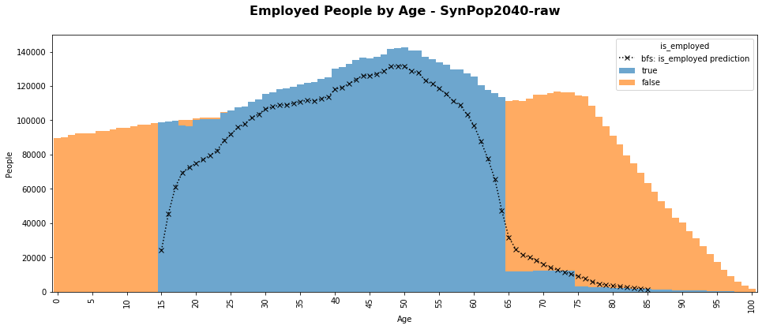

```python
title = f'Employed People by Age - SynPop{YEAR}-raw'

ax = plot_binary_feature_per_age_with_marginals(counts_per_cat,
                                                expected_true_counts,
                                                colour_dict=COLOUR_DICT,
                                                ymax=150_000,
                                                y_grid=True,
                                                title=title
                                               )

save_figure(SAVE_OUTPUTS, f'05a_SynPop{YEAR}_raw_is_employed_by_age.{FIG_FORMAT}',
            OUTPUT_DIR, FIG_DPI, FIG_FORMAT, FIG_BBOX_INCHES, FIG_PAD_INCHES)
```

**Year IST**

```python
%%time
marginals_ist = marginal_fitting.compute_bfs_vs_scenario_marginal_summary_table(persons_ist,
                                                                                bfs_predicted_ratio_ist,
                                                                                YEAR_IST,
                                                                                feature='is_employed',
                                                                                control_level_list=['age']
                                                                               )
```

```
Wall time: 8.25 s
```

```python
counts_per_cat_ist = (marginals_ist
                      .reset_index()
                      .astype({'is_employed': str})  # to avoid boolean values as column names
                      .pivot(index='age', columns='is_employed', values=f'counts_{YEAR_IST}')
                      .rename(columns={'True': 'true', 'False': 'false'})  # to avoid confusion between bool and str
                      .fillna(0).astype(int)
                      )
counts_per_cat_ist = counts_per_cat_ist[['true', 'false']]
```

```python
expected_true_counts_ist =  (marginals_ist[f'expected_counts_{YEAR_IST}']
                             .reset_index()
                             .query('is_employed')
                             .astype({'is_employed': str})  # to avoid boolean values as column names
                             .groupby('age').sum().iloc[:, 0]
                             .rename('bfs: is_employed prediction')
                             )
expected_true_counts_ist.index = list(expected_true_counts_ist.index)  # otherwise, categorical
```

```
2020-04-22 17:09:50,268 - INFO - root: Figure saved to file : ./outputs\05a_SynPop2017_is_employed_by_age.png
```

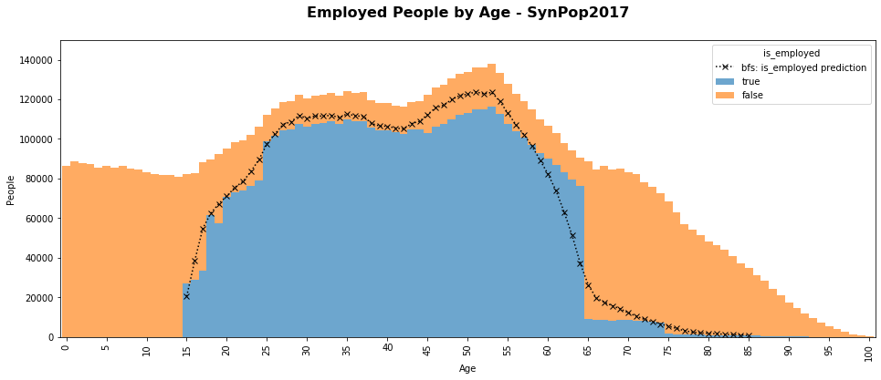

```python
title = f'Employed People by Age - SynPop{YEAR_IST}'

ax = plot_binary_feature_per_age_with_marginals(counts_per_cat_ist,
                                                expected_true_counts_ist,
                                                colour_dict=COLOUR_DICT,
                                                ymax=150_000,
                                                y_grid=True,
                                                title=title
                                               )

save_figure(SAVE_OUTPUTS, f'05a_SynPop{YEAR_IST}_is_employed_by_age.{FIG_FORMAT}',
            OUTPUT_DIR, FIG_DPI, FIG_FORMAT, FIG_BBOX_INCHES, FIG_PAD_INCHES)
```

## Cross-Relationships

**Scenario Year**

**CT1**

```
2020-04-22 17:09:59,319 - INFO - root: Figure saved to file : ./outputs\05a_CT1_SynPop2040_raw.png
```

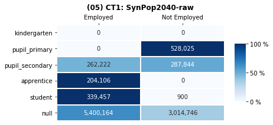

```python
ax, ct1 = plot_ct1(persons, title=f'(05) CT1: SynPop{YEAR}-raw')

save_figure(SAVE_OUTPUTS, f'05a_CT1_SynPop{YEAR}_raw.{FIG_FORMAT}',
            OUTPUT_DIR, FIG_DPI, FIG_FORMAT, FIG_BBOX_INCHES, FIG_PAD_INCHES)
```

**CT2**

```
2020-04-22 17:10:06,910 - INFO - root: Figure saved to file : ./outputs\05a_CT2_SynPop2040_raw.png
```

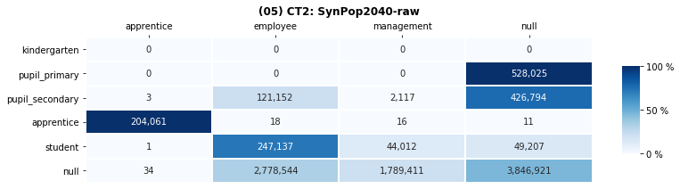

```python
ax, ct2 = plot_ct2(persons, title=f'(05) CT2: SynPop{YEAR}-raw')

save_figure(SAVE_OUTPUTS, f'05a_CT2_SynPop{YEAR}_raw.{FIG_FORMAT}',
            OUTPUT_DIR, FIG_DPI, FIG_FORMAT, FIG_BBOX_INCHES, FIG_PAD_INCHES)
```

**CT3**

```
2020-04-22 17:10:15,399 - INFO - root: Figure saved to file : ./outputs\05a_CT3_SynPop2040_raw.png
```

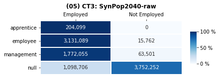

```python
ax, ct3 = plot_ct3(persons, title=f'(05) CT3: SynPop{YEAR}-raw')

save_figure(SAVE_OUTPUTS, f'05a_CT3_SynPop{YEAR}_raw.{FIG_FORMAT}',
            OUTPUT_DIR, FIG_DPI, FIG_FORMAT, FIG_BBOX_INCHES, FIG_PAD_INCHES)
```

**Year IST**

**CT1**

```
2020-04-22 17:10:22,785 - INFO - root: Figure saved to file : ./outputs\05a_CT1_SynPop2017.png
```

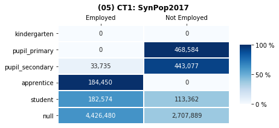

```python
ax, ct1_ist = plot_ct1(persons_ist, title=f'(05) CT1: SynPop{YEAR_IST}')

save_figure(SAVE_OUTPUTS, f'05a_CT1_SynPop{YEAR_IST}.{FIG_FORMAT}',
            OUTPUT_DIR, FIG_DPI, FIG_FORMAT, FIG_BBOX_INCHES, FIG_PAD_INCHES)
```

**CT2**

```
2020-04-22 17:10:29,608 - INFO - root: Figure saved to file : ./outputs\05a_CT2_SynPop2017.png
```

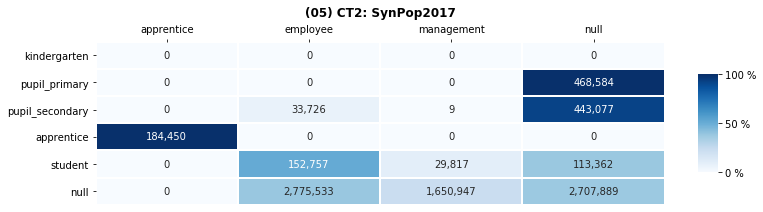

```python
ax, ct2_ist = plot_ct2(persons_ist, title=f'(05) CT2: SynPop{YEAR_IST}')

save_figure(SAVE_OUTPUTS, f'05a_CT2_SynPop{YEAR_IST}.{FIG_FORMAT}',
            OUTPUT_DIR, FIG_DPI, FIG_FORMAT, FIG_BBOX_INCHES, FIG_PAD_INCHES)
```

**CT3**

```
2020-04-22 17:10:36,928 - INFO - root: Figure saved to file : ./outputs\05a_CT3_SynPop2017.png
```

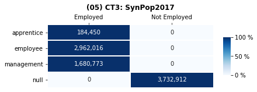

```python
ax, ct3_ist = plot_ct3(persons_ist, title=f'(05) CT3: SynPop{YEAR_IST}')

save_figure(SAVE_OUTPUTS, f'05a_CT3_SynPop{YEAR_IST}.{FIG_FORMAT}',
            OUTPUT_DIR, FIG_DPI, FIG_FORMAT, FIG_BBOX_INCHES, FIG_PAD_INCHES)
```

# SMART Fixing methodology

## Expected Counts

```python
%%time
# marginals without unemployment
marginals_2 = marginal_fitting.compute_bfs_vs_scenario_marginal_summary_table(persons,
                                                                              bfs_without_unemployed,
                                                                              YEAR,
                                                                              feature='is_employed',
                                                                              control_level_list=['age']
                                                                             )
```

```
Wall time: 10.1 s
```

```python
expected_pop_counts = (marginals_2
                       .reset_index()
                       .astype({'is_employed': str})  # to avoid boolean values as column names
                       .pivot(index='age', columns='is_employed', values=f'expected_counts_{YEAR}')
                       .rename(columns={'True': 'true', 'False': 'false'})  # to avoid confusion between bool and str
                       .fillna(0).astype(int)
                       )
expected_pop_counts = expected_pop_counts[['true', 'false']]
```

## Probability Model

```python
ct_empl_ist = marginal_fitting.compute_cross_table(persons_ist,
                                                   main_feature='is_employed',
                                                   secondary_features=['current_edu', 'current_job_rank']
                                                   )
```

```python
ct_empl_ist.head()
```

| current_edu | is_employed current_job_rank | False | True |
| --- | --- | --- | --- |
| kindergarten | apprentice | 0 | 0 |
|  | employee | 0 | 0 |
|  | management | 0 | 0 |
|  | null | 0 | 0 |
| pupil_primary | apprentice | 0 | 0 |

```python
%%time
person_proba = marginal_fitting.build_person_proba_with_from_cross_table(
    persons, ct_empl_ist,
    merge_on=['current_edu', 'current_job_rank']
)
```

```
Wall time: 5.93 s
```

## Fixing...

The logging can be set to `INFO` or `DEBUG` (at the top of the notebook `logger.setLevel(logging.INFO)`) based on how much detail is needed!

```python
logger.setLevel(logging.INFO)
```

```python
fixed_empl = marginal_fitting.fix_categorical_feature(persons=persons,
                                                      feature='is_employed',
                                                      pop_segment_variables=['age'],
                                                      control_totals=expected_pop_counts,
                                                      person_proba=person_proba
                                                      )

fixed_empl = fixed_empl == 'true'  # Turning it back into a boolean
```

```
2020-04-22 17:11:11,969 - INFO - synpop.marginal_fitting: Fixing "is_employed" by population segments based on: ['age']
2020-04-22 17:11:23,829 - INFO - synpop.marginal_fitting: 20 / 132 population segments fixed...
2020-04-22 17:11:26,085 - INFO - synpop.marginal_fitting: 40 / 132 population segments fixed...
2020-04-22 17:11:29,103 - INFO - synpop.marginal_fitting: 60 / 132 population segments fixed...
2020-04-22 17:11:31,356 - INFO - synpop.marginal_fitting: 80 / 132 population segments fixed...
2020-04-22 17:11:32,015 - INFO - synpop.marginal_fitting: 100 / 132 population segments fixed...
2020-04-22 17:11:32,251 - INFO - synpop.marginal_fitting: 120 / 132 population segments fixed...
2020-04-22 17:11:32,391 - INFO - synpop.marginal_fitting: All 132 population segments fixed!
```

```python
persons_fixed = persons.copy(deep=True)
persons_fixed = persons_fixed.drop('is_employed', axis=1)
persons_fixed = pd.merge(persons_fixed, fixed_empl, left_on='person_id', right_index=True)
persons_fixed.shape
```

```
(10037464, 16)
```

# Examining SynPop+ before applying consistentcy rules

## Global Counts

```python
%%time
summary_table_fixed = marginal_fitting.compute_comparison_summary(persons_fixed, persons_ist,
                                                                  YEAR, YEAR_IST,
                                                                  groupby='is_employed')
```

```
Wall time: 14.9 s
```

```python
print('As reference, the total population growth is: {:.2f}'.format(persons.shape[0] / persons_ist.shape[0]))
summary_table_fixed
```

```
As reference, the total population growth is: 1.17
```

| is_employed | counts_2017 | counts_2040 | growth | prop_2017 | prop_2040 |
| --- | --- | --- | --- | --- | --- |
| False | 3732912 | 4827932 | 1.29 | 0.44 | 0.48 |
| True | 4827239 | 5209532 | 1.08 | 0.56 | 0.52 |

## Marginals per Age

**Fixed SynPop**

```python
%%time
marginals_fixed = marginal_fitting.compute_bfs_vs_scenario_marginal_summary_table(persons_fixed,
                                                                                  bfs_predicted_ratio,
                                                                                  YEAR,
                                                                                  feature='is_employed',
                                                                                  control_level_list=['age']
                                                                                 )

counts_per_cat_fixed = (marginals_fixed
                       .reset_index()
                       .astype({'is_employed': str})  # to avoid boolean values as column names
                       .pivot(index='age', columns='is_employed', values=f'counts_{YEAR}')
                       .rename(columns={'True': 'true', 'False': 'false'})  # to avoid confusion between bool and str
                       )
counts_per_cat_fixed = counts_per_cat_fixed[['true', 'false']]

expected_true_counts_fixed =  (marginals_fixed[f'expected_counts_{YEAR}']
                               .reset_index()
                               .query('is_employed')
                               .astype({'is_employed': str})  # to avoid boolean values as column names
                               .groupby('age').sum().iloc[:, 0]
                               .rename('bfs: is_employed prediction')
                               )
expected_true_counts_fixed.index = list(expected_true_counts_fixed.index)  # otherwise, categorical
```

```
Wall time: 9.59 s
```

```
2020-04-22 17:12:17,925 - INFO - root: Figure saved to file : ./outputs\05a_SynPop2040Plus_is_employed_by_age_no_consistency.png
```

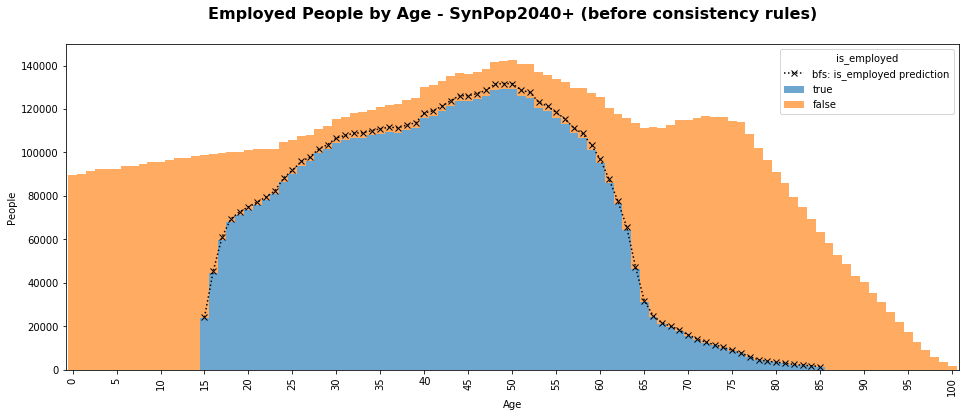

```python
title = f'Employed People by Age - SynPop{YEAR}+ (before consistency rules)'

ax = plot_binary_feature_per_age_with_marginals(counts_per_cat_fixed,
                                                expected_true_counts,
                                                colour_dict=COLOUR_DICT,
                                                ymax=150_000,
                                                y_grid=True,
                                                title=title
                                               )

save_figure(SAVE_OUTPUTS, f'05a_SynPop{YEAR}Plus_is_employed_by_age_no_consistency.{FIG_FORMAT}',
            OUTPUT_DIR, FIG_DPI, FIG_FORMAT, FIG_BBOX_INCHES, FIG_PAD_INCHES)
```

## Cross-Relationships

**Fixed SynPop**

**CT1**

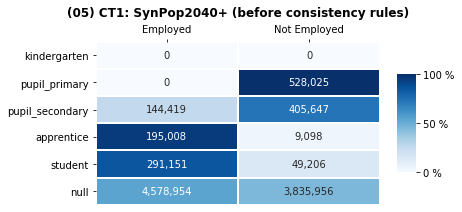

```python
ax, ct1_fixed = plot_ct1(persons_fixed, title=f'(05) CT1: SynPop{YEAR}+ (before consistency rules)')
```

**CT2**

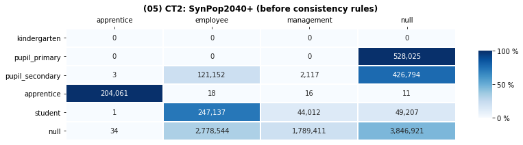

```python
ax, ct2_fixed = plot_ct2(persons_fixed, title=f'(05) CT2: SynPop{YEAR}+ (before consistency rules)')
```

**CT3**

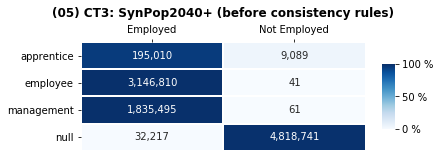

```python
ax, ct3_fixed = plot_ct3(persons_fixed, title=f'(05) CT3: SynPop{YEAR}+ (before consistency rules)')
```

# Forcing some Cross-Relationships Consistency Rules

For some age the control totals did not match perfectly so the cross relationships could not nicely be reproduced. Here I will force the structures that are important to us and see how much change is needed.

- It is important that the total number of apprentice, students and pupils match

```python
KEY_COLUMNS = ['person_id', 'age', 'current_edu', 'current_job_rank', 'is_employed']
```

```python
persons_forced = persons_fixed[KEY_COLUMNS].copy(deep=True)
```

## Forcing CT2 & CT3

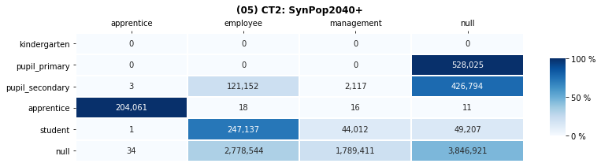

```python
_ = plot_ct2(persons_forced, title=f'(05) CT2: SynPop{YEAR}+')
```

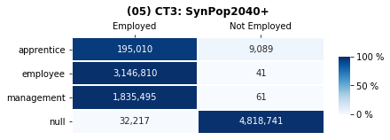

```python
_ = plot_ct3(persons_forced, title=f'(05) CT3: SynPop{YEAR}+')
```

```python
# Forcing CT2
mask = persons_forced['current_edu'] == 'apprentice'
persons_forced['current_job_rank'] = persons_forced['current_job_rank'].mask(mask, 'apprentice')

mask = (persons_forced['current_edu'] != 'apprentice') & (persons_forced['current_job_rank'] == 'apprentice')
persons_forced['current_job_rank'] = persons_forced['current_job_rank'].mask(mask, 'null')
```

```python
# Forcing CT3
mask = persons_forced['current_job_rank'].isin(['apprentice', 'employee', 'management'])
persons_forced['is_employed'] = persons_forced['is_employed'].mask(mask, True)

mask = persons_forced['current_job_rank'] == 'null'
persons_forced['is_employed'] = persons_forced['is_employed'].mask(mask, False)
```

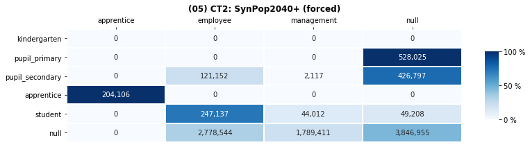

```python
_ = plot_ct2(persons_forced, title=f'(05) CT2: SynPop{YEAR}+ (forced)')
```

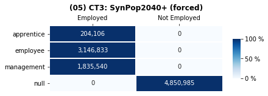

```python
_ = plot_ct3(persons_forced, title=f'(05) CT3: SynPop{YEAR}+ (forced)')
```

## Forcing CT1

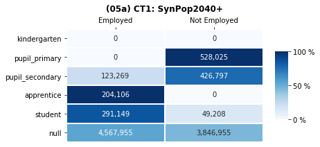

```python
ax, ct1_fixed = plot_ct1(persons_forced, title=f'(05a) CT1: SynPop{YEAR}+')
```

```python
ist_scaled = ct1_ist.div(ct1_ist.sum(axis=1), axis=0).fillna(0).mul(ct1_fixed.sum(axis=1), axis=0)
ct1_diff = (ct1_fixed - ist_scaled).astype(int)
print('Difference between fixed and forced:')
ct1_diff
```

```
Difference between fixed and forced:
```

| is_employed | Employed | Not Employed |
| --- | --- | --- |
| kindergarten | 0 | 0 |
| pupil_primary | 0 | 0 |
| pupil_secondary | 84351 | -84351 |
| apprentice | 0 | 0 |
| student | 81170 | -81170 |
| null | -653029 | 653029 |

**Notes:**

- We have too many pupils and students working
- We need to change some that are working to: "is_employed" = 0 and "current_job_rank" = "null"
- There is no other way but to be tinkery at this point...

**The changes that will be done:**

- All pupils_secondary which are "management" --> "null"
- Reproduce 2017 CT1 structure by chaning the remaining pupils_secondary which are "employee" --> "null"
- 10'000 students which are "management" --> "null"
- Reproduce 2017 CT1 structure by chaning the remaining students which are "employee" --> "null"
- Compensate by changing agents that have current_job_rant = "null" and current_edu="null" --> "employee"

```python
def sample_non_active_persons(persons_df, persons_per_age):
    person_pool_mask = ((persons_df['current_edu'] == 'null') &
                        (persons_df['current_job_rank'] == 'null')
                        )
    weights = persons_forced['age'].map(persons_per_age.to_dict()).fillna(0) ** 2  #  why? These weights just work!
    person_ids_to_change = persons_df[person_pool_mask].sample(persons_per_age.sum(), weights=weights)['person_id'].values

    return person_ids_to_change
```

**Fixing the pupil_secondary that should not be working**

```python
%%time
# All pupils_secondary - management --> null
mask = (persons_forced['current_edu'] == 'pupil_secondary') & (persons_forced['current_job_rank'] == 'management')
persons_forced['current_job_rank'] = persons_forced['current_job_rank'].mask(mask, 'null')
persons_forced['is_employed'] = persons_forced['is_employed'].mask(mask, False)

persons_changed = persons_forced[mask].groupby('age').count().iloc[:, 0].rename('persons_changed')

# Compensate for lost employment
person_ids_to_change = sample_non_active_persons(persons_forced, persons_changed)
sampled_mask = persons_forced['person_id'].isin(person_ids_to_change)

persons_forced['current_job_rank'] = persons_forced['current_job_rank'].mask(sampled_mask, 'employee')
persons_forced['is_employed'] = persons_forced['is_employed'].mask(sampled_mask, True)
```

```
Wall time: 5.13 s
```

```python
%%time
# Fix rest with pupils_secondary - employee --> null
pupils_to_change = ct1_diff.loc['pupil_secondary', 'Employed'] - persons_changed.sum()
pupils_pool_mask = (persons_forced['current_edu'] == 'pupil_secondary') & (persons_forced['current_job_rank'] == 'employee')

pupils_to_change_mask = persons_forced['person_id'].isin(persons_forced[pupils_pool_mask].sample(pupils_to_change)['person_id'].values)

persons_forced['current_job_rank'] = persons_forced['current_job_rank'].mask(pupils_to_change_mask, 'null')
persons_forced['is_employed'] = persons_forced['is_employed'].mask(pupils_to_change_mask, False)

persons_changed = persons_forced[pupils_to_change_mask].groupby('age').count().iloc[:, 0].rename('persons_changed')

# Compensate for lost employment
person_ids_to_change = sample_non_active_persons(persons_forced, persons_changed)
sampled_mask = persons_forced['person_id'].isin(person_ids_to_change)

persons_forced['current_job_rank'] = persons_forced['current_job_rank'].mask(sampled_mask, 'employee')
persons_forced['is_employed'] = persons_forced['is_employed'].mask(sampled_mask, True)
```

```
Wall time: 5.41 s
```

**Fixing the students that should not be working**

```python
%%time
# 10'000 students - management --> null
students_to_change = 10_000  # Based on what CT2 should look like
student_pool_mask = (persons_forced['current_edu'] == 'student') & (persons_forced['current_job_rank'] == 'management')

students_to_change_mask = persons_forced['person_id'].isin(persons_forced[student_pool_mask].sample(students_to_change)['person_id'].values)

persons_forced['current_job_rank'] = persons_forced['current_job_rank'].mask(students_to_change_mask, 'null')
persons_forced['is_employed'] = persons_forced['is_employed'].mask(students_to_change_mask, False)

persons_changed = persons_forced[students_to_change_mask].groupby('age').count().iloc[:, 0].rename('persons_changed')

# Compensate for lost employment
person_ids_to_change = sample_non_active_persons(persons_forced, persons_changed)
sampled_mask = persons_forced['person_id'].isin(person_ids_to_change)

persons_forced['current_job_rank'] = persons_forced['current_job_rank'].mask(sampled_mask, 'employee')
persons_forced['is_employed'] = persons_forced['is_employed'].mask(sampled_mask, True)
```

```
Wall time: 5.15 s
```

```python
%%time
# Fix rest with students - employee --> null
students_to_change = ct1_diff.loc['student', 'Employed'] - persons_changed.sum()
student_pool_mask = (persons_forced['current_edu'] == 'student') & (persons_forced['current_job_rank'] == 'employee')

students_to_change_mask = persons_forced['person_id'].isin(persons_forced[student_pool_mask].sample(students_to_change)['person_id'].values)

persons_forced['current_job_rank'] = persons_forced['current_job_rank'].mask(students_to_change_mask, 'null')
persons_forced['is_employed'] = persons_forced['is_employed'].mask(students_to_change_mask, False)

persons_changed = persons_forced[students_to_change_mask].groupby('age').count().iloc[:, 0].rename('persons_changed')

# Compensate for lost employment
person_ids_to_change = sample_non_active_persons(persons_forced, persons_changed)
sampled_mask = persons_forced['person_id'].isin(person_ids_to_change)

persons_forced['current_job_rank'] = persons_forced['current_job_rank'].mask(sampled_mask, 'employee')
persons_forced['is_employed'] = persons_forced['is_employed'].mask(sampled_mask, True)
```

```
Wall time: 5.66 s
```

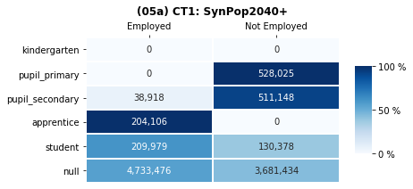

```python
ax, ct1_forced = plot_ct1(persons_forced, title=f'(05a) CT1: SynPop{YEAR}+')
```

# Examining SynPop+ after applying consistency rules

## Marginals Per Age

**Is Employed**

```python
%%time
marginals_forced = marginal_fitting.compute_bfs_vs_scenario_marginal_summary_table(persons_forced,
                                                                                   bfs_predicted_ratio,
                                                                                   YEAR,
                                                                                   feature='is_employed',
                                                                                   control_level_list=['age']
                                                                                  )

counts_per_cat_forced = (marginals_forced
                         .reset_index()
                         .astype({'is_employed': str})  # to avoid boolean values as column names
                         .pivot(index='age', columns='is_employed', values=f'counts_{YEAR}')
                         .rename(columns={'True': 'true', 'False': 'false'})  # to avoid confusion between bool and str
                         )
counts_per_cat_forced = counts_per_cat_forced[['true', 'false']]

expected_true_counts_forced =  (marginals_forced[f'expected_counts_{YEAR}']
                               .reset_index()
                               .query('is_employed')
                               .astype({'is_employed': str})  # to avoid boolean values as column names
                               .groupby('age').sum().iloc[:, 0]
                               .rename('bfs: is_employed prediction')
                               )
expected_true_counts_forced.index = list(expected_true_counts_forced.index)  # otherwise, categorical
```

```
Wall time: 3.67 s
```

```
2020-04-22 17:13:23,201 - INFO - root: Figure saved to file : ./outputs\05a_SynPop2040Plus_is_employed_by_age_FINAL.png
```

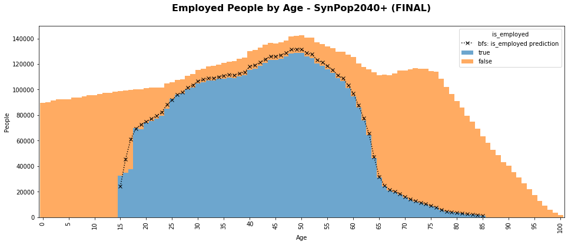

```python
title = f'Employed People by Age - SynPop{YEAR}+ (FINAL)'

ax = plot_binary_feature_per_age_with_marginals(counts_per_cat_forced,
                                                expected_true_counts,
                                                colour_dict=COLOUR_DICT,
                                                ymax=150_000,
                                                y_grid=True,
                                                title=title
                                               )

save_figure(SAVE_OUTPUTS, f'05a_SynPop{YEAR}Plus_is_employed_by_age_FINAL.{FIG_FORMAT}',
            OUTPUT_DIR, FIG_DPI, FIG_FORMAT, FIG_BBOX_INCHES, FIG_PAD_INCHES)
```

**Current Education**

```python
marginals_edu = marginal_fitting.compute_ist_vs_scenario_marginal_counts(persons_forced, persons_ist,
                                                                         YEAR, YEAR_IST,
                                                                         feature='current_edu',
                                                                         control_level_list=['age']
                                                                         )

counts_per_cat_edu = (marginals_edu
                      .reset_index()
                      .pivot(index='age', columns='current_edu', values='counts_{}'.format(YEAR))
                      )

counts_per_cat_edu = counts_per_cat_edu[persons['current_edu'].cat.categories]
```

```
2020-04-22 17:13:34,803 - INFO - root: Figure saved to file : ./outputs\05a_SynPop2040Plus_current_edu_by_age_FINAL.png
```

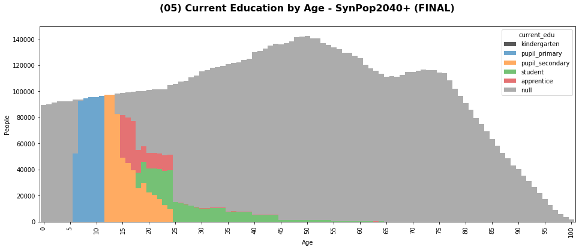

```python
title = f'(05) Current Education by Age - SynPop{YEAR}+ (FINAL)'
edu_color_dict = {'kindergarten': 'k', 'pupil_primary': 'C0', 'pupil_secondary': 'C1', 'student': 'C2',
                  'apprentice': 'C3',  'null': 'grey'}

ax = plot_multi_class_feature_per_age(counts_per_cat_edu, colour_dict=edu_color_dict, ymax=150_000, title=title)

save_figure(SAVE_OUTPUTS, f'05a_SynPop{YEAR}Plus_current_edu_by_age_FINAL.{FIG_FORMAT}',
            OUTPUT_DIR, FIG_DPI, FIG_FORMAT, FIG_BBOX_INCHES, FIG_PAD_INCHES)
```

**Current Job Rank**

```python
marginals_job = marginal_fitting.compute_ist_vs_scenario_marginal_counts(persons_forced, persons_ist,
                                                                         YEAR, YEAR_IST,
                                                                         feature='current_job_rank',
                                                                         control_level_list=['age'])

counts_per_cat_job = (marginals_job
                      .reset_index()
                      .pivot(index='age', columns='current_job_rank', values=f'counts_{YEAR}')
                      )

counts_per_cat_job = counts_per_cat_job[persons['current_job_rank'].cat.categories]
```

```
2020-04-22 17:13:46,010 - INFO - root: Figure saved to file : ./outputs\05a_SynPop2040Plus_current_job_rank_by_age_FINAL.png
```

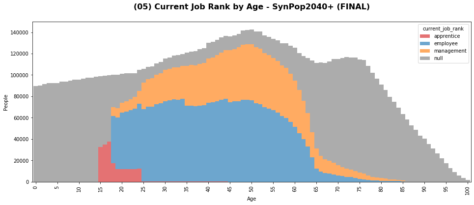

```python
title = f'(05) Current Job Rank by Age - SynPop{YEAR}+ (FINAL)'
job_color_dict = {'employee': 'C0', 'management': 'C1', 'apprentice': 'C3',  'null': 'grey'}

ax = plot_multi_class_feature_per_age(counts_per_cat_job, colour_dict=job_color_dict, ymax=150_000, title=title)

save_figure(SAVE_OUTPUTS, f'05a_SynPop{YEAR}Plus_current_job_rank_by_age_FINAL.{FIG_FORMAT}',
            OUTPUT_DIR, FIG_DPI, FIG_FORMAT, FIG_BBOX_INCHES, FIG_PAD_INCHES)
```

## Cross-Relationships

**CT1**

```
2020-04-22 17:13:49,259 - INFO - root: Figure saved to file : ./outputs\05a_CT1_SynPop2040Plus_FINAL.png
```

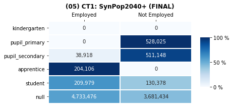

```python
ax, ct1_forced = plot_ct1(persons_forced, title=f'(05) CT1: SynPop{YEAR}+ (FINAL)')

save_figure(SAVE_OUTPUTS, f'05a_CT1_SynPop{YEAR}Plus_FINAL.{FIG_FORMAT}',
            OUTPUT_DIR, FIG_DPI, FIG_FORMAT, FIG_BBOX_INCHES, FIG_PAD_INCHES)
```

**CT2**

```
2020-04-22 17:13:51,121 - INFO - root: Figure saved to file : ./outputs\05a_CT2_SynPop2040Plus_FINAL.png
```

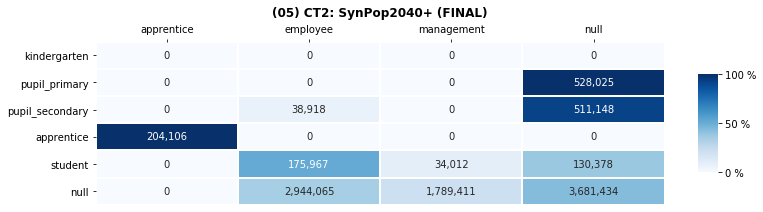

```python
ax, ct2_forced = plot_ct2(persons_forced, title=f'(05) CT2: SynPop{YEAR}+ (FINAL)')

save_figure(SAVE_OUTPUTS, f'05a_CT2_SynPop{YEAR}Plus_FINAL.{FIG_FORMAT}',
            OUTPUT_DIR, FIG_DPI, FIG_FORMAT, FIG_BBOX_INCHES, FIG_PAD_INCHES)
```

**CT3**

```
2020-04-22 17:13:53,760 - INFO - root: Figure saved to file : ./outputs\05a_CT3_SynPop2040Plus_FINAL.png
```

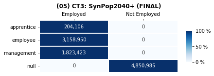

```python
ax, ct3_forced = plot_ct3(persons_forced, title=f'(05) CT3: SynPop{YEAR}+ (FINAL)')

save_figure(SAVE_OUTPUTS, f'05a_CT3_SynPop{YEAR}Plus_FINAL.{FIG_FORMAT}',
            OUTPUT_DIR, FIG_DPI, FIG_FORMAT, FIG_BBOX_INCHES, FIG_PAD_INCHES)
```

# Saving Results

```python
OUTPUT_DIR
```

```
'./outputs'
```

```python
%%time
if SAVE_OUTPUTS:
    results_file = os.path.join(OUTPUT_DIR, 'fixed_is_employed_SMART.pickle.gzip')
    persons_forced.set_index('person_id')['is_employed'].to_pickle(results_file, compression='gzip')
```

# Export Notebook to HTML

```python
### Write notebook to a html file
!jupyter nbconvert --to html 05a_SMART_Marginal_Fitting_Is_Employed.ipynb
```